# Feature Selection Framework

RHESSysML Capstone Group

2/5/2022

# Introduction

The following R Markdown document describes the necessary steps to determine important relationships between predictor variables and a response variable in RHESSys model output. Specific code examples will be based on RHESSys model output from the Sagehen Creek Experimental Watershed in the Sierra Nevada, CA. The data set incorporates model parameter uncertainty, topographic spatial variability, and climate change scenarios. The data set and associated metadata can be accessed here: https://www.hydroshare.org/resource/2a31bd57b7e74c758b7857679ffbb4c5/.

The following research question will be addressed in this process: **What are the most important predictors of Net Primary Productivity in differing climate scenarios?**

# Data Preparation

## Load Data

```r
df <- read_csv(here("data", "sageres.csv"))
```

## Clean and Aggregate Data

First, RHESSys output will need to be aggregated and cleaned based on specific research question. Possible changes include:

1. Changing the temporal resolution (i.e. Daily to Yearly measurements).
2. Converting variable units (i.e. Radians to Degrees).
3. Converting variable class (i.e. numeric/character to factor).
4. Creating derived variables (i.e. Peak SWE).

The code chunk below identifies the variables in our data set that will be converted to factors, variables that will be used to aggregate by water year, and the desired response variable.

```r
## USER INPUTS
group_cols <- c("wy", "stratumID", "clim", "scen", "topo")
factor_vars <- c("wy", "stratumID", "clim", "scen", "topo")
response_var <- "npp"
```

Next, the necessary modifications to the data set are made. For this example, we are converting factor variables, aggregating by water year, changing `slope` and `aspect` from radians to degrees, and adding two derived variables: `peak_swe` and `swe_precip_ratio`. Since this data set contains two climate scenarios, we split these up into two data frames

TO DO: ADD DERIVED VARIABLES (SWE AND MONTHLY TEMPS) **DONE (maybe?)**

```r
## Convert categorical variables to factors
df[,factor_vars] <- lapply(df[,factor_vars], factor)

df_wy <- df %>%
  ## Change aspect and splope from radians to degrees
  mutate(aspect=aspect*(180/pi),
         slope=slope*(180/pi)) %>%
  group_by(across(all_of(group_cols))) %>%
  mutate(jun_tavg = mean(tavg[month == 6]),
         jul_tavg = mean(tavg[month == 7]),
         aug_tavg = mean(tavg[month == 8]),
         sep_tavg = mean(tavg[month == 9]),
         oct_tavg = mean(tavg[month == 10]),
         nov_tavg = mean(tavg[month == 11]),
         dec_tavg = mean(tavg[month == 12]),
         jan_tavg = mean(tavg[month == 1]),
         feb_tavg = mean(tavg[month == 2]),
         mar_tavg = mean(tavg[month == 3]),
         apr_tavg = mean(tavg[month == 4]),
         may_tavg = mean(tavg[month == 5])) %>%
  mutate(peak_swe=max(swe)) %>%
  mutate(swe_precip_ratio=peak_swe/sum(precip)) %>%
  summarise_if(is.numeric, mean) %>%
  ungroup() %>%
  ## Reorder response variables first
  select(!!response_var, everything()) %>%
  ## Remove unwanted variables (manually?)
  select(-c(tavg, day, month, year, basinID, hillID, zoneID, patchID))

## Create data frame with only climate scenario 0
df_wy0 <- df_wy %>%
  filter(clim==0) %>%
  select(-c(clim, wy))

## Create data frame with only climate scenario 2
df_wy2 <- df_wy %>%
  filter(clim==2) %>%
  select(-c(clim, wy))
```

Now, we have two data tables representing the two climate scenarios.

# Data Description

Next, we want to get a summary description of the data set. This is crucial for many reasons:

1. Shows early on in the process if any variables do not have the expected range, magnitude, class, etc.
2. Provides information on data set characteristics that are important for decisions later on in the machine learning process.

```r
summarize_data <- function(df) {
  df_name <- deparse(substitute(df))
  describe(df) %>%
    select(vars, n, mean, sd, min, max, range) %>%
    mutate(class = lapply(df, class)) %>%
    kable(digits=4,
          align="r",
          caption=paste0("Summary of ", df_name)) %>%
    kable_styling(bootstrap_options = c("striped", "hover"))
}

summarize_data(df_wy0)
```

Summary of df_wy0

|  | vars | n | mean | sd | min | max | range | class |
| --- | --- | --- | --- | --- | --- | --- | --- | --- |
| npp | 1 | 1620 | 0.0009 | 0.0004 | 0.0000 | 0.0031 | 0.0031 | numeric |
| stratumID* | 2 | 1620 | 3.5000 | 1.7084 | 1.0000 | 6.0000 | 5.0000 | factor |
| scen* | 3 | 1620 | 3.0000 | 1.4147 | 1.0000 | 5.0000 | 4.0000 | factor |
| topo* | 4 | 1620 | 2.0000 | 0.8167 | 1.0000 | 3.0000 | 2.0000 | factor |
| lai | 5 | 1620 | 2.4499 | 0.4954 | 1.4539 | 4.0685 | 2.6146 | numeric |
| height | 6 | 1620 | 25.8880 | 6.8449 | 14.0750 | 41.1483 | 27.0733 | numeric |
| plantc | 7 | 1620 | 8.8459 | 2.2486 | 4.7804 | 16.0058 | 11.2254 | numeric |
| cpool | 8 | 1620 | 2.0500 | 0.5271 | 1.0115 | 3.6893 | 2.6778 | numeric |
| swe | 9 | 1620 | 0.0148 | 0.0163 | 0.0004 | 0.0937 | 0.0933 | numeric |
| precip | 10 | 1620 | 0.0018 | 0.0008 | 0.0008 | 0.0039 | 0.0031 | numeric |
| trans | 11 | 1620 | 0.0014 | 0.0004 | 0.0004 | 0.0024 | 0.0020 | numeric |
| evap | 12 | 1620 | 0.0003 | 0.0001 | 0.0001 | 0.0005 | 0.0004 | numeric |
| sat_deficit | 13 | 1620 | 2.5089 | 0.4104 | 1.4031 | 3.3363 | 1.9332 | numeric |
| rz_storage | 14 | 1620 | 0.3350 | 0.0810 | 0.1751 | 0.5781 | 0.4030 | numeric |
| tmax | 15 | 1620 | 14.0527 | 1.0010 | 11.4265 | 16.1547 | 4.7282 | numeric |
| tmin | 16 | 1620 | -3.7401 | 0.7988 | -5.5455 | -1.5573 | 3.9882 | numeric |
| aspect | 17 | 1620 | 180.3461 | 122.1473 | 16.0734 | 313.3067 | 297.2333 | numeric |
| slope | 18 | 1620 | 8.6661 | 5.2039 | 1.8873 | 15.4066 | 13.5193 | numeric |
| elev | 19 | 1620 | 1949.6445 | 16.0382 | 1932.9000 | 1977.3000 | 44.4000 | numeric |
| jun_tavg | 20 | 1620 | 10.9302 | 1.6583 | 5.9922 | 14.1892 | 8.1970 | numeric |
| jul_tavg | 21 | 1620 | 14.3084 | 1.5338 | 11.7022 | 17.3221 | 5.6199 | numeric |
| aug_tavg | 22 | 1620 | 13.7127 | 1.2934 | 9.6799 | 16.3060 | 6.6260 | numeric |
| sep_tavg | 23 | 1620 | 10.3645 | 1.2557 | 7.0561 | 12.5835 | 5.5274 | numeric |
| oct_tavg | 24 | 1620 | 5.2220 | 1.5964 | -0.3103 | 8.4727 | 8.7830 | numeric |
| nov_tavg | 25 | 1620 | 0.4537 | 1.5788 | -4.3005 | 4.6460 | 8.9465 | numeric |
| dec_tavg | 26 | 1620 | -3.3241 | 1.8061 | -7.1092 | 0.0734 | 7.1826 | numeric |
| jan_tavg | 27 | 1620 | -3.0945 | 1.8800 | -6.7477 | 1.1521 | 7.8998 | numeric |
| feb_tavg | 28 | 1620 | -2.0514 | 1.6764 | -6.3321 | 1.7802 | 8.1122 | numeric |
| mar_tavg | 29 | 1620 | 0.2439 | 1.6127 | -3.3536 | 3.8920 | 7.2456 | numeric |
| apr_tavg | 30 | 1620 | 2.7750 | 1.7849 | -1.8614 | 6.4065 | 8.2679 | numeric |
| may_tavg | 31 | 1620 | 6.9138 | 1.5982 | 3.3496 | 11.0714 | 7.7218 | numeric |
| peak_swe | 32 | 1620 | 0.1234 | 0.0951 | 0.0079 | 0.5477 | 0.5398 | numeric |
| swe_precip_ratio | 33 | 1620 | 0.1865 | 0.1234 | 0.0191 | 0.6878 | 0.6687 | numeric |

```r
summarize_data(df_wy2)
```

Summary of df_wy2

|  | vars | n | mean | sd | min | max | range | class |
| --- | --- | --- | --- | --- | --- | --- | --- | --- |
| npp | 1 | 1620 | 0.0008 | 0.0004 | -0.0003 | 0.0033 | 0.0036 | numeric |
| stratumID* | 2 | 1620 | 3.5000 | 1.7084 | 1.0000 | 6.0000 | 5.0000 | factor |
| scen* | 3 | 1620 | 8.0000 | 1.4147 | 6.0000 | 10.0000 | 4.0000 | factor |
| topo* | 4 | 1620 | 2.0000 | 0.8167 | 1.0000 | 3.0000 | 2.0000 | factor |
| lai | 5 | 1620 | 2.3018 | 0.4321 | 1.3939 | 3.8391 | 2.4452 | numeric |
| height | 6 | 1620 | 25.2526 | 6.4786 | 14.0760 | 38.1647 | 24.0886 | numeric |
| plantc | 7 | 1620 | 8.3806 | 2.1359 | 4.3624 | 15.0073 | 10.6449 | numeric |
| cpool | 8 | 1620 | 1.9498 | 0.5308 | 0.9775 | 3.7023 | 2.7248 | numeric |
| swe | 9 | 1620 | 0.0047 | 0.0088 | 0.0000 | 0.0674 | 0.0674 | numeric |
| precip | 10 | 1620 | 0.0018 | 0.0008 | 0.0008 | 0.0039 | 0.0031 | numeric |
| trans | 11 | 1620 | 0.0014 | 0.0004 | 0.0004 | 0.0024 | 0.0020 | numeric |
| evap | 12 | 1620 | 0.0003 | 0.0001 | 0.0001 | 0.0006 | 0.0004 | numeric |
| sat_deficit | 13 | 1620 | 2.5416 | 0.4127 | 1.3792 | 3.3336 | 1.9544 | numeric |
| rz_storage | 14 | 1620 | 0.3238 | 0.0790 | 0.1723 | 0.5711 | 0.3988 | numeric |
| tmax | 15 | 1620 | 16.0527 | 1.0010 | 13.4265 | 18.1547 | 4.7282 | numeric |
| tmin | 16 | 1620 | -1.7401 | 0.7988 | -3.5455 | 0.4427 | 3.9882 | numeric |
| aspect | 17 | 1620 | 180.3461 | 122.1473 | 16.0734 | 313.3067 | 297.2333 | numeric |
| slope | 18 | 1620 | 8.6661 | 5.2039 | 1.8873 | 15.4066 | 13.5193 | numeric |
| elev | 19 | 1620 | 1949.6445 | 16.0382 | 1932.9000 | 1977.3000 | 44.4000 | numeric |
| jun_tavg | 20 | 1620 | 12.9302 | 1.6583 | 7.9922 | 16.1892 | 8.1970 | numeric |
| jul_tavg | 21 | 1620 | 16.3084 | 1.5338 | 13.7022 | 19.3221 | 5.6199 | numeric |
| aug_tavg | 22 | 1620 | 15.7127 | 1.2934 | 11.6799 | 18.3060 | 6.6260 | numeric |
| sep_tavg | 23 | 1620 | 12.3645 | 1.2557 | 9.0561 | 14.5835 | 5.5274 | numeric |
| oct_tavg | 24 | 1620 | 7.2220 | 1.5964 | 1.6897 | 10.4727 | 8.7830 | numeric |
| nov_tavg | 25 | 1620 | 2.4537 | 1.5788 | -2.3005 | 6.6460 | 8.9465 | numeric |
| dec_tavg | 26 | 1620 | -1.3241 | 1.8061 | -5.1092 | 2.0734 | 7.1826 | numeric |
| jan_tavg | 27 | 1620 | -1.0945 | 1.8800 | -4.7477 | 3.1521 | 7.8998 | numeric |
| feb_tavg | 28 | 1620 | -0.0514 | 1.6764 | -4.3321 | 3.7802 | 8.1122 | numeric |
| mar_tavg | 29 | 1620 | 2.2439 | 1.6127 | -1.3536 | 5.8920 | 7.2456 | numeric |
| apr_tavg | 30 | 1620 | 4.7750 | 1.7849 | 0.1386 | 8.4065 | 8.2679 | numeric |
| may_tavg | 31 | 1620 | 8.9138 | 1.5982 | 5.3496 | 13.0714 | 7.7218 | numeric |
| peak_swe | 32 | 1620 | 0.0584 | 0.0595 | 0.0000 | 0.3854 | 0.3854 | numeric |
| swe_precip_ratio | 33 | 1620 | 0.0907 | 0.0907 | 0.0000 | 0.5202 | 0.5202 | numeric |

We can also look at the key study area characteristics. In this study, there are six study areas.

```r
topos <- df_wy %>%
  filter(clim==0) %>%
  select(c(stratumID, topo, elev, aspect, slope)) %>%
  group_by(stratumID, topo) %>%
  summarize_if(is.numeric, mean) %>%
  mutate(topo = case_when(topo == "M" ~ "Mid-Slope",
                          topo == "U" ~ "Upslope",
                          topo == "R" ~ "Riparian")) %>%
  dplyr::arrange(topo) %>%
  rename("Stratum"=stratumID,
         "Topo"=topo,
         "Elevation (m)"=elev,
         "Aspect (degrees CCW from East)"=aspect,
         "Slope (degrees)"=slope)

kable(topos,
      digits=2,
      caption="Summary of 6 Study Areas in Sagehen Creek",
      align=c("l", rep("r", ncol(topos) - 1))) %>%
  kable_styling(bootstrap_options = c("striped", "hover"))
```

Summary of 6 Study Areas in Sagehen Creek

| Stratum | Topo | Elevation (m) | Aspect (degrees CCW from East) | Slope (degrees) |
| --- | --- | --- | --- | --- |
| 37679011 | Mid-Slope | 1937.60 | 313.31 | 7.88 |
| 42316011 | Mid-Slope | 1959.07 | 85.58 | 8.47 |
| 38569011 | Riparian | 1934.80 | 287.39 | 3.27 |
| 38571011 | Riparian | 1932.90 | 16.07 | 1.89 |
| 36815011 | Upslope | 1956.20 | 299.82 | 15.09 |
| 43583011 | Upslope | 1977.30 | 79.91 | 15.41 |

# Remove Multicollinearity

TO DO: ADD SOURCES FOR THIS SECTION

## Identify and Remove Correlated Variables

First, we create data frames containing only the predictor variables to assist with the next steps.

```r
## Find number of response variables specified
num_response <- length(response_var)

## Save data frames of predictor variables for first climate scenario
numericpredictors.df_wy0 <- df_wy0[,(num_response+1):ncol(df_wy0)] %>% select(where(is.numeric))
allpredictors.df_wy0 <- df_wy0[,(num_response+1):ncol(df_wy0)]
factorpredictors.df_wy0 <- df_wy0[,(num_response+1):ncol(df_wy0)] %>% select(where(is.factor))

## Save data frames of predictor variables for second climate scenario
numericpredictors.df_wy2 <- df_wy2[,(num_response+1):ncol(df_wy2)] %>% select(where(is.numeric))
allpredictors.df_wy2 <- df_wy2[,(num_response+1):ncol(df_wy2)]
factorpredictors.df_wy2 <- df_wy2[,(num_response+1):ncol(df_wy2)] %>% select(where(is.factor))
```

**Do we want to do this preliminary imp process for clim 2 as well?**

```r
## First climate scenario

## Find preliminary importance using random forest
imp <- rf(data=df_wy,
          dependent.variable.name=response_var,
          predictor.variable.names=colnames(allpredictors.df_wy0),
          verbose=FALSE)

## Set preference order based on variable importance.
preference.order <- imp$importance$per.variable$variable

## Preference order can be determined manually for variables of interest:
#preference.order <- c("precip", "rz_storage", "trans", "evap")

## Remove variables based on VIF and Correlation thresholds
remove_multicollinearity <- function(vif.threshold=5, cor.threshold=0.75, predictors.df) {
  variable.selection <- auto_vif(x=predictors.df,
                                 vif.threshold=vif.threshold,
                                 preference.order=preference.order) %>%
    auto_cor(cor.threshold=cor.threshold,
             preference.order=preference.order)

  variable.selection$selected.variables
}
```

TO DO: ADD SOURCE FOR SELECTING THRESHOLDS

```r
## Create list of selected variables
wy0_select_variables <- remove_multicollinearity(vif.threshold=5, cor.threshold=0.75, predictors.df=allpredictors.df_wy0)
```

```
## [auto_vif()]: Removed variables: height, cpool, swe, slope, elev, sep_tavg, oct_tavg, nov_tavg, mar_tavg, swe_precip_ratio
```

```
## [auto_cor()]: Removed variables: sat_deficit
```

```r
wy2_select_variables <- remove_multicollinearity(vif.threshold=5, cor.threshold=0.75, predictors.df=allpredictors.df_wy2)
```

```
## [auto_vif()]: Removed variables: height, cpool, swe, aspect, oct_tavg, nov_tavg, feb_tavg, mar_tavg, swe_precip_ratio
```

```
## [auto_cor()]: Removed variables: slope, sat_deficit
```

```r
## Remove numeric variables with multicollinearity
df_wy0_reduced <- df_wy0 %>%
  select(c(all_of(response_var), colnames(factorpredictors.df_wy0), all_of(wy0_select_variables)))

df_wy2_reduced <- df_wy2 %>%
  select(c(all_of(response_var), colnames(factorpredictors.df_wy2), all_of(wy2_select_variables)))
```

## Summary of Removed Variables

TO DO: CREATE SUMMARY AND VISUALIZATIONS OF VARIABLES REMOVED. use warning messages for guidance.

**Added plots of preliminary importance and VIF showing selected and removed variables and summary table containing all that info. Maybe we could include a pairs plot too to show correlation, or include max correlation plot / summary.**

```r
# creating df with preliminary variable importance (and rank) and whether each was selected or removed
removed_importance0 <- imp$variable.importance %>%
  data.frame() %>%
  rownames_to_column("variable") %>%
  rename("importance" = ".") %>%
  mutate("importance_rank" = rank(-importance)) %>%
  mutate(selected = case_when(variable %in% wy0_select_variables ~ "selected",
                              !variable %in% wy0_select_variables ~ "removed")) %>%
  relocate("selected", .after = "variable")

# creating df of VIFs
removed_vif0 <- vif(allpredictors.df_wy0)
```

```
## Warning in vif(allpredictors.df_wy0): These columns are non-numeric and will be
## removed: stratumID, scen, topo
```

```
## Warning in vif(allpredictors.df_wy0): These columns have zero variance and might
## cause issues: precip, trans, evap
```

```r
# joining dfs to create summary table of removed and selected variables
removed_summary0 <- removed_importance0 %>%
  left_join(removed_vif0, by = "variable")

removed_imp0_plot <- ggplot(removed_summary0, aes(x = importance, y = reorder(variable, importance), fill = selected)) +
  geom_col() +
  labs(x = "Preliminary Importance", y = "Variable")

removed_vif0_plot <- ggplot(removed_summary0, aes(x = vif, y = reorder(variable, vif), fill = selected)) +
  geom_col() +
  labs(x = "Variable Inflation Factor", y = "Variable")

removed_summary0 %>%
  select(-importance) %>%
  kable(caption="Selected and removed variables",
                            format.args=list()) %>%
  kable_styling(bootstrap_options = c("striped", "hover"))
```

Selected and removed variables

| variable | selected | importance_rank | vif |
| --- | --- | --- | --- |
| stratumID | removed | 30 | NA |
| scen | removed | 29 | NA |
| topo | removed | 32 | NA |
| lai | selected | 24 | 4.558 |
| height | removed | 28 | 1.476 |
| plantc | selected | 7 | 23.753 |
| cpool | removed | 14 | 22.458 |
| swe | removed | 6 | 16.974 |
| precip | selected | 1 | 11.653 |
| trans | selected | 5 | 6.117 |
| evap | selected | 4 | 3.905 |
| sat_deficit | removed | 9 | 6.160 |
| rz_storage | selected | 2 | 5.095 |
| tmax | selected | 10 | 41.656 |
| tmin | selected | 12 | 42.602 |
| aspect | selected | 31 | 4.822 |
| slope | removed | 27 | 11.451 |
| elev | removed | 25 | 14.770 |
| jun_tavg | selected | 11 | 6.264 |
| jul_tavg | selected | 19 | 8.003 |
| aug_tavg | selected | 13 | 5.926 |
| sep_tavg | removed | 20 | 5.315 |
| oct_tavg | removed | 22 | 3.844 |
| nov_tavg | removed | 23 | 5.238 |
| dec_tavg | selected | 16 | 6.775 |
| jan_tavg | selected | 17 | 7.923 |
| feb_tavg | selected | 21 | 4.922 |
| mar_tavg | removed | 26 | 5.669 |
| apr_tavg | selected | 15 | 8.052 |
| may_tavg | selected | 18 | 5.140 |
| peak_swe | selected | 3 | 41.624 |
| swe_precip_ratio | removed | 8 | 16.682 |

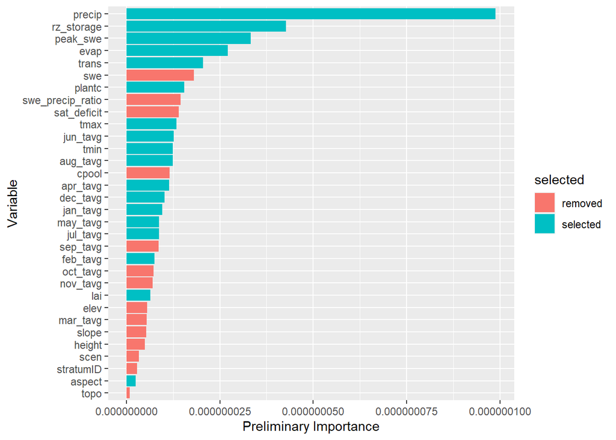

```r
removed_imp0_plot
```

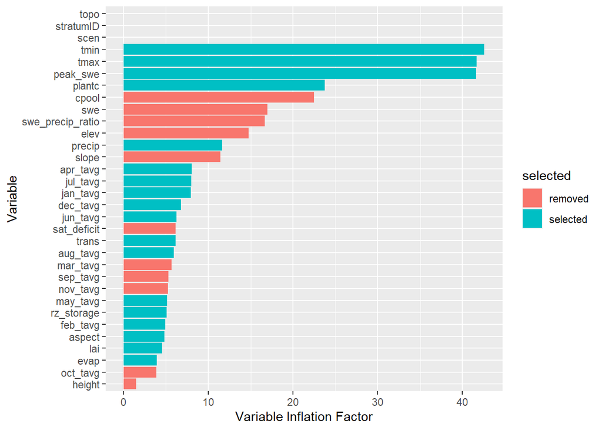

```r
removed_vif0_plot
```

# Feature Importance

TO DO: ADD DESCRIPTIONS AND SOURCES TO THIS SECTION

TO DO: ADD MORE RANDOM FOREST MODELS AND IMPORTANCE METRICS

```r
set.seed(4326)
## Random Forest package with replace=FALSE
rf_wy0 <- randomForest(formula=npp~.,
                       data=df_wy0_reduced,
                       replace=TRUE,
                       importance=TRUE,
                       keep.forest=TRUE,
                       keep.inbag=TRUE)

set.seed(4326)
## Random Forest package with replace=FALSE
rf_wy2 <- randomForest(formula=npp~.,
                       data=df_wy2_reduced,
                       replace=TRUE,
                       importance=TRUE,
                       keep.forest=TRUE,
                       keep.inbag=TRUE)
```

TO DO: ADD DESCRIPTIONS AND SOURCES TO THIS SECTION

```r
imp_wy0 <- permimp(rf_wy0,
                   #conditional=TRUE,
                   do_check=FALSE, progressBar=FALSE)

imp_wy2 <- permimp(rf_wy2,
                   #conditional=TRUE,
                   do_check=FALSE, progressBar=FALSE)
```

TO DO: ADD CROSS VALIDATION (10-Fold) (https://www.ncbi.nlm.nih.gov/pmc/articles/PMC6049094/)

# Visualize Results

Now, we can visualize the results of the Random Forest feature selection.

```r
imp_to_table <- function(imp) {
  df_permimp <- imp$values %>%
    data.frame() %>%
    rownames_to_column("Variable") %>%
    rename("Importance"=".") %>%
    mutate(Rank=rank(-Importance))
}

df_imp_wy0 <- imp_to_table(imp_wy0)
df_imp_wy2 <- imp_to_table(imp_wy2)

rank_importance <- function(df_imp) {
  df_name <- deparse(substitute(df_imp))
  df_imp_wy0 %>%
  select(Variable, Rank) %>%
  arrange(Rank) %>%
  kable(align="r",
        caption=paste0("Variable importance rank for ", df_name)) %>%
  kable_styling(bootstrap_options = c("striped", "hover"))
}

rank_importance(df_imp_wy0)
```

Variable importance rank for df_imp_wy0

| Variable | Rank |
| --- | --- |
| precip | 1 |
| rz_storage | 2 |
| evap | 3 |
| plantc | 4 |
| trans | 5 |
| peak_swe | 6 |
| tmin | 7 |
| aug_tavg | 8 |
| scen | 9 |
| jun_tavg | 10 |
| tmax | 11 |
| dec_tavg | 12 |
| jul_tavg | 13 |
| may_tavg | 14 |
| apr_tavg | 15 |
| stratumID | 16 |
| feb_tavg | 17 |
| jan_tavg | 18 |
| lai | 19 |
| topo | 20 |
| aspect | 21 |

```r
rank_importance(df_imp_wy2)
```

Variable importance rank for df_imp_wy2

[output not shown]

The following table shows the relative importance of predictor variables between the two climate scenarios.

```r
df_imp <- df_imp_wy0 %>%
  full_join(df_imp_wy2, by="Variable") %>%
  mutate(Diff = Rank.x-Rank.y) %>%
  select(-c(Importance.x, Importance.y)) %>%
  rename("Rank (0)" = Rank.x,
         "Rank (2)" = Rank.y) %>%
  arrange(`Rank (0)`)

df_imp %>%
  kable(align="r",
        caption="Difference in variable importance for the two climate scenarios") %>%
  kable_styling(bootstrap_options = c("striped", "hover")) %>%
  column_spec(column=4,
              color=ifelse(is.na(df_imp$Diff), "grey",
                           ifelse(df_imp$Diff>0, "green",
                                  ifelse(df_imp$Diff==0, "grey", "red"))))
```

Difference in variable importance for the two climate scenarios

| Variable | Rank (0) | Rank (2) | Diff |
| --- | --- | --- | --- |
| precip | 1 | 1 | 0 |
| rz_storage | 2 | 2 | 0 |
| evap | 3 | 5 | -2 |
| plantc | 4 | 7 | -3 |
| trans | 5 | 4 | 1 |
| peak_swe | 6 | 3 | 3 |
| tmin | 7 | 10 | -3 |
| aug_tavg | 8 | 6 | 2 |
| scen | 9 | 8 | 1 |
| jun_tavg | 10 | 9 | 1 |
| tmax | 11 | 12 | -1 |
| dec_tavg | 12 | 17 | -5 |
| jul_tavg | 13 | 15 | -2 |
| may_tavg | 14 | 13 | 1 |
| apr_tavg | 15 | 11 | 4 |
| stratumID | 16 | 19 | -3 |
| feb_tavg | 17 | NA | NA |
| jan_tavg | 18 | 14 | 4 |
| lai | 19 | 18 | 1 |
| topo | 20 | 21 | -1 |
| aspect | 21 | NA | NA |
| sep_tavg | NA | 16 | NA |
| elev | NA | 20 | NA |

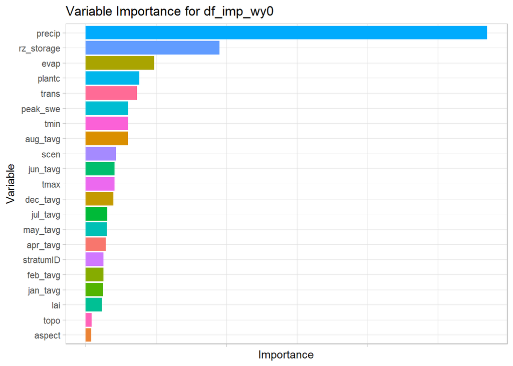

```r
plot_imp <- function(imp_df) {
  df_name <- deparse(substitute(imp_df))
  ggplot(data=imp_df, aes(x=Importance, y=reorder(Variable, Importance), fill=Variable)) +
    geom_col() +
    theme_light() +
    theme(legend.position = "none",
          axis.text.x = element_blank()) +
    labs(title=paste0("Variable Importance for ", df_name),
         x="Importance",
         y="Variable")
}

wy0_plot <- plot_imp(df_imp_wy0)
wy2_plot <- plot_imp(df_imp_wy2)

wy0_plot
```

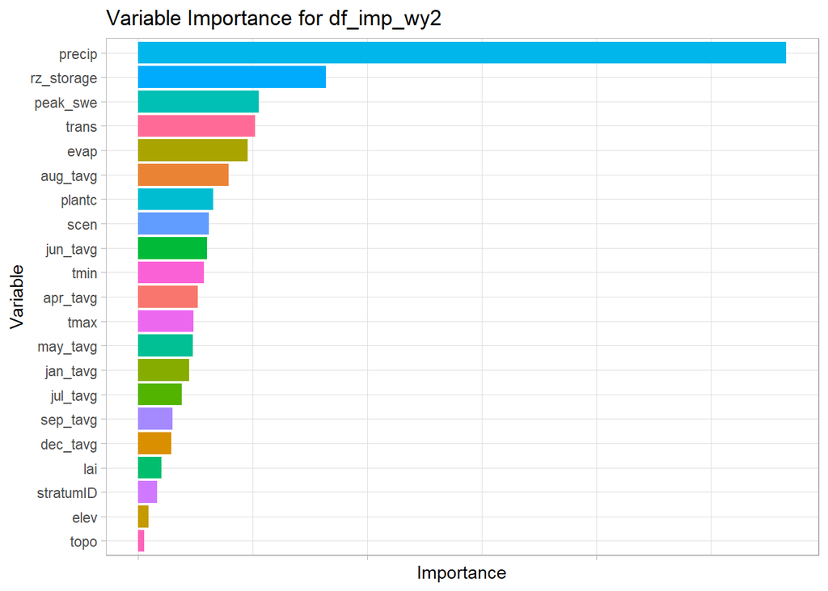

```r
wy2_plot
```

TO DO: INCLUDE MORE VISUALIZATIONS, INCLUDING CV RESULTS, PLOTS OF IMPORTANT VARIABLE RELATIONSHIPS, ETC.

TO DO: INCLUDE VISUALIZATIONS COMPARING RF MODELS, DIFFERENT IMPORTANCE MEASURES

OVERALL TO DO: TEST, CHECK, AND CORRECT ALL INCORRECT ASSUMPTIONS, CHOICES, ETC. THAT LEAD TO INCORRECT RESULTS OR UNDESIRABLE WORKFLOW